# CEO SALARY ANALYSIS

F. Eren Dalçık / 11752009

13 06 2021

# PAPER INTRODUCTION

In this project, I defined 4 questions related to ceosal data.

I started to answer the questions with an analysis of the data set.

I assigned the data to a dataset named “ceodata” using the tidyverse library and “read_dta()” function.

## Data Analysis and Exploration

```
##      salary         pcsalary          sales              roe
##  Min.   :  223   Min.   :-61.00   Min.   :  175.2   Min.   : 0.50
##  1st Qu.:  736   1st Qu.: -1.00   1st Qu.: 2210.3   1st Qu.:12.40
##  Median : 1039   Median :  9.00   Median : 3705.2   Median :15.50
##  Mean   : 1281   Mean   : 13.28   Mean   : 6923.8   Mean   :17.18
##  3rd Qu.: 1407   3rd Qu.: 20.00   3rd Qu.: 7177.0   3rd Qu.:20.00
##  Max.   :14822   Max.   :212.00   Max.   :97649.9   Max.   :56.30
##      pcroe            ros            indus           finance
##  Min.   :-98.9   Min.   :-58.0   Min.   :0.0000   Min.   :0.0000
##  1st Qu.:-21.2   1st Qu.: 21.0   1st Qu.:0.0000   1st Qu.:0.0000
##  Median : -3.0   Median : 52.0   Median :0.0000   Median :0.0000
##  Mean   : 10.8   Mean   : 61.8   Mean   :0.3206   Mean   :0.2201
##  3rd Qu.: 19.5   3rd Qu.: 81.0   3rd Qu.:1.0000   3rd Qu.:0.0000
##  Max.   :977.0   Max.   :418.0   Max.   :1.0000   Max.   :1.0000
##     consprod         utility          lsalary          lsales
##  Min.   :0.0000   Min.   :0.0000   Min.   :5.407   Min.   : 5.166
##  1st Qu.:0.0000   1st Qu.:0.0000   1st Qu.:6.601   1st Qu.: 7.701
##  Median :0.0000   Median :0.0000   Median :6.946   Median : 8.217
##  Mean   :0.2871   Mean   :0.1722   Mean   :6.950   Mean   : 8.292
##  3rd Qu.:1.0000   3rd Qu.:0.0000   3rd Qu.:7.249   3rd Qu.: 8.879
##  Max.   :1.0000   Max.   :1.0000   Max.   :9.604   Max.   :11.489
```

*We have 209 observations and 12 variables in “ceosal” CEO Salaries data. These variables are:*

*1. salary 1990 CEO salary, thousands $,* *2. pcsalary % change salary, 89-90,* *3. sales 1990 firm sales, millions $,* *4. roe return on equity, 88-90 avg,* *5. pcroe % change roe, 88-90,* *6. ros return on firm’s stock, 88-90,* *7. indus dummy variable for sector; it is equal 1 if industrial firm,* *8. finance dummy variable for sector; it is equal 1 if financial firm,* *9. consprod dummy variable for sector; it is equal 1 if consumer product firm,* *10. utility dummy variable for sector; it is 1 if transport. or utilties firm,* *11. lsalary log of salary,*  
*12. lsales log of sales.*

#### Following Plots and Analyses are About the “ceosal” data.

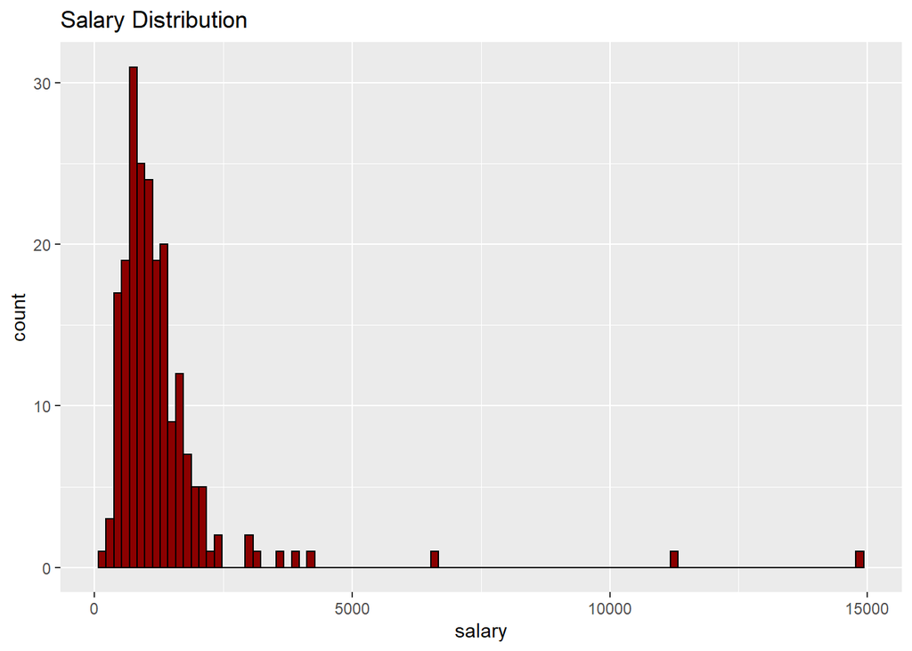

This is a simple salary distribution histogram plot of the CEO’s. We can see that it is right-skewed.

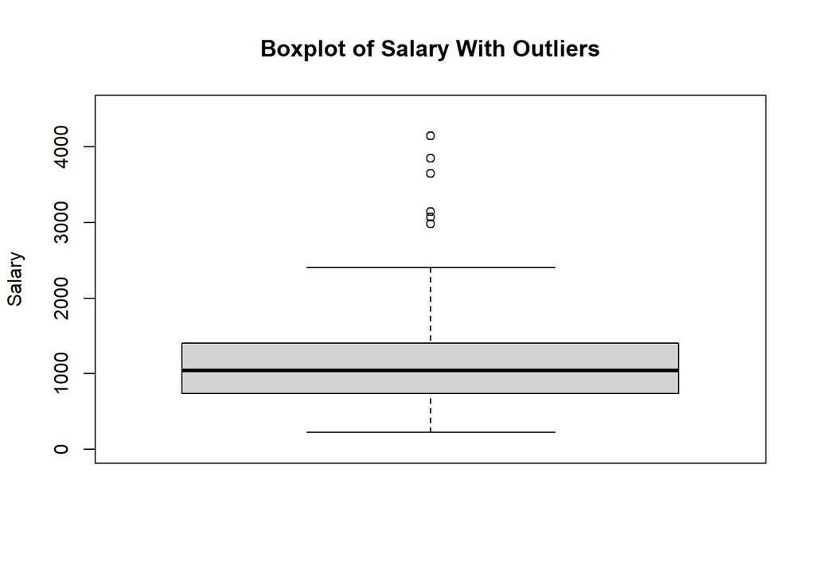

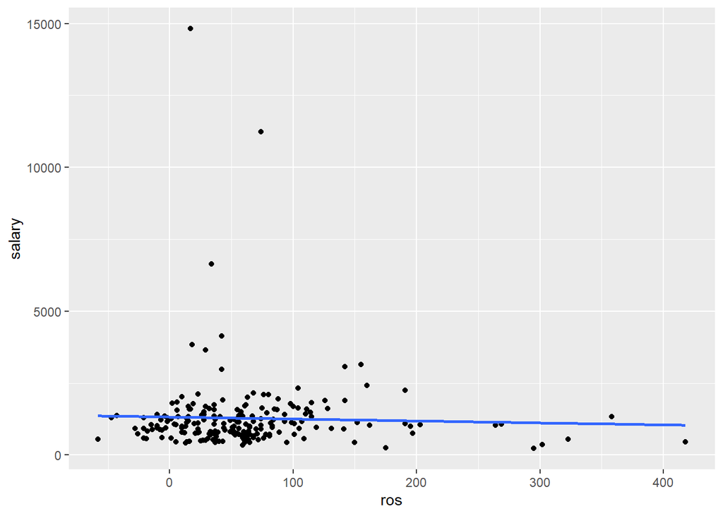

From this plot, we can see that there is a negative linear relationship between the salary of the CEO and the ros variable.

## Project Questions

### Question 1:

### In terms of the model parameters, state the null hypothesis that, after controlling for sales and roe, ros has no effect on CEO salary. State the alternative that better stock market performance increases a CEO’s salary.

```
H0 : β3 = 0. H1 : β3 > 0
```

### Question 2:

### Using the ceosal data frame,

### a) Summarize and interpret the variables of the model to estimate using statistical tools and graphics.

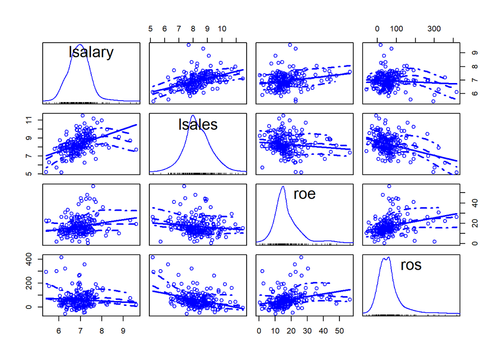

[output not shown]

### b) Estimate the model of CEO salary using OLS.

```
##
## Call:
## lm(formula = lsalary ~ lsales + roe + pcroe + ros + indus + finance +
##     consprod, data = ceodata)
##
## Residuals:
##      Min       1Q   Median       3Q      Max
## -1.07935 -0.21811 -0.02486  0.16787  2.64858
##
## Coefficients:
##               Estimate Std. Error t value Pr(>|t|)
## (Intercept)  4.3532156  0.3063648  14.209  < 2e-16 ***
## lsales       0.2522809  0.0342031   7.376 4.19e-12 ***
## roe          0.0112601  0.0043394   2.595  0.01016 *
## pcroe        0.0004849  0.0003338   1.452  0.14793
## ros         -0.0001828  0.0005490  -0.333  0.73944
## indus        0.2784600  0.0995684   2.797  0.00566 **
## finance      0.4277926  0.1040339   4.112 5.71e-05 ***
## consprod     0.4679376  0.1104598   4.236 3.46e-05 ***
## ---
## Signif. codes:  0 '***' 0.001 '**' 0.01 '*' 0.05 '.' 0.1 ' ' 1
##
## Residual standard error: 0.4596 on 201 degrees of freedom
## Multiple R-squared:  0.3636, Adjusted R-squared:  0.3414
## F-statistic:  16.4 on 7 and 201 DF,  p-value: < 2.2e-16
```

### c) Using diagnosis tests for the estimated model, validate the assumptions of OLS.

[output not shown]

### d) Interpret the estimated model.

[output not shown]

### e)By what percentage is salary predicted to increase if ros increases by 50 points? Does ros have a practically large effect on salary?

```
##
## Call:
## lm(formula = lsalary ~ lsales + roe + ros, data = ceodata)
##
## Residuals:
##      Min       1Q   Median       3Q      Max
## -0.96060 -0.27144 -0.03264  0.22563  2.79805
##
## Coefficients:
##              Estimate Std. Error t value Pr(>|t|)
## (Intercept) 4.3117125  0.3154329  13.669  < 2e-16 ***
## lsales      0.2803149  0.0353200   7.936 1.34e-13 ***
## roe         0.0174168  0.0040923   4.256 3.17e-05 ***
## ros         0.0002417  0.0005418   0.446    0.656
## ---
## Signif. codes:  0 '***' 0.001 '**' 0.01 '*' 0.05 '.' 0.1 ' ' 1
##
## Residual standard error: 0.4832 on 205 degrees of freedom
## Multiple R-squared:  0.2827, Adjusted R-squared:  0.2722
## F-statistic: 26.93 on 3 and 205 DF,  p-value: 1.001e-14
```

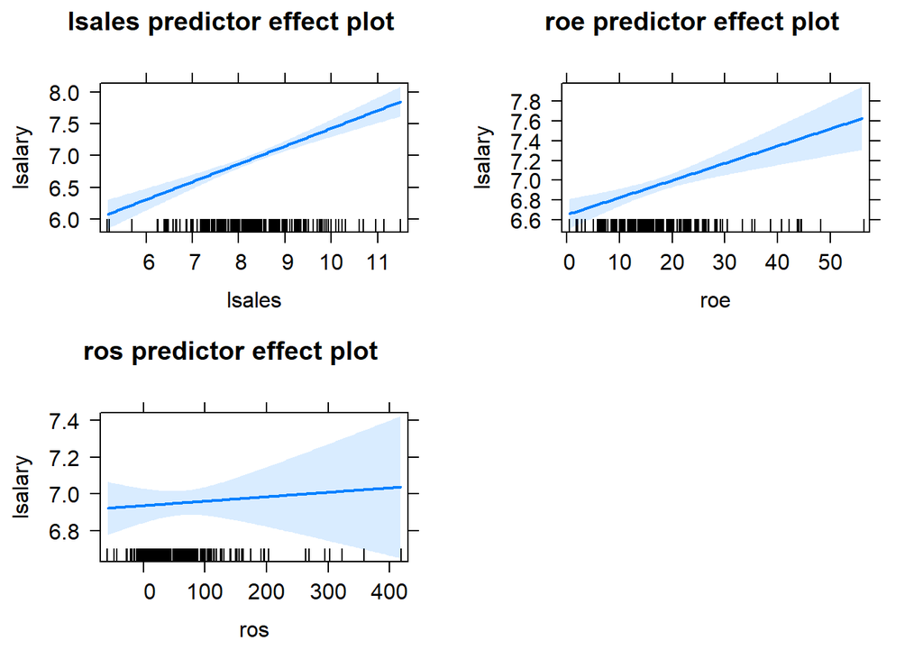

[output not shown]

[output not shown]

### Question 3:

### Test the null hypothesis that ros has no effect on salary against the alternative that ros has a positive effect. Carry out the test at the 10%, 5%, and 1% significance level.

```
Critical value for the test using df = 200 is 1.29 in table. The t-stat on ros is .00024 / .00054 = .44. It is way below the critical value in the table. We fail to reject the H0 at the 10% significance level.
```

### Question 4:

### Would you include ros in a final model explaining CEO compensation in terms of firm performance? Explain.

[output not shown]